# Causal Inference - Exercise DiD

Michael Knaus

SoSe 25

These are the goals of this notebook:

- Replicate Card and Krueger (1994) to illustrate 2x2 difference-in-differences

# Card and Krueger (1994) - a revolutionary paper

```
if (!require("estimatr")) install.packages("estimatr", dependencies = TRUE); library(estimatr)
if (!require("tidyverse")) install.packages("tidyverse", dependencies = TRUE); library(tidyverse)
if (!require("did")) install.packages("did", dependencies = TRUE); library(did)
if (!require("haven")) install.packages("haven", dependencies = TRUE); library(haven)
if (!require("fixest")) install.packages("fixest", dependencies = TRUE); library(fixest)
if (!require("panelView")) install.packages("panelView", dependencies = TRUE); library(panelView)
if (!require("usmap")) install.packages("usmap", dependencies = TRUE); library(usmap)
```

Let’s set some `ggplot` defaults to save some space:

```
# Set the defaults for plotting:
custom_colors = c("#023E8A", "#FFB703")
options(ggplot2.discrete.colour = custom_colors)
options(ggplot2.discrete.fill = custom_colors)
update_geom_defaults("text", list(hjust = -0.1, vjust = -0.5, fontface = "bold"))

custom_theme = theme_grey(base_size = 12) +
  theme(plot.title = element_text(face = "bold", hjust = 0.5),
        legend.text = element_text(size = 8),
        legend.title = element_text(size = 10, face = "bold"),
        strip.text = element_text(size = 12))
theme_set(custom_theme)
```

## General remarks

[Card and Krueger (1994)](https://www.aru-learning.com/images/informacion/Card-Krueger-1994.pdf) is probably the most widely used example to introduce 2x2 DiD. There would be plenty of interesting more recent alternatives, but I stick to the tradition because it is groundbreaking in two dimensions:

- One of the earliest uses of 2x2 DiD in Economics
- The finding revolutionized the way how economists think about minimum wages. It challenged the dominant view that markets are perfect and that minimum wages lead to employment loss. However, if companies have market power, i.e. the labor market is a [monopsony](https://en.wikipedia.org/wiki/Monopsony#Static_monopsony_in_a_labour_market), minimum wages can increase employment.

This pissed off the establishment as you can read [in this short note in the Wall Street Journal](https://www.aei.org/carpe-diem/quotation-of-the-day-james-buchanan-on-the-minimum-wage/) of a Nobel laureate James Buchanan who dismissed the empirical findings because they did not fit into his perfect markets mindset. I quote “…we have not yet become a bevy of camp-following whores.”. Well, that escalated quickly and shows that Card and Krueger (1994) were onto something.

Since then economists not only build models but also test them empirically making it a more scientific field.

## What the paper is about

The paper of Card and Krueger (1994) investigates the impact of a minimum wage increase in 1992 New Jersey raising from $4.25 an hour to $5.05 an hour on employment levels in the fast food industry. The neighboring state Pennsylvania did not raise the minimum wage in the meantime.

The researchers collected employment levels from fast food restaurants in both states before and after a minimum wage increase in New Jersey to run a DiD analysis.

We will use the following variables:

- `Y1` and `Y2` which is the employment in full-time equivalents (FTE) before and after the minimum wage increase, respectively.
- `W` dummy variable being 1 if restaurant being in New Jersey (treated) and 0 if in Pennsylvania (control)

## Prepare the data

Load the data. Each row is a restaurant, i.e. there is no time index. Data are in the wide, not the long format.

```
# Inspired by https://aaronmams.github.io/Card-Krueger-Replication/
tempfile_path = tempfile()
download.file("http://davidcard.berkeley.edu/data_sets/njmin.zip", destfile = tempfile_path)
```

```
versuche URL 'http://davidcard.berkeley.edu/data_sets/njmin.zip'
```

```
tempdir_path = tempdir()
unzip(tempfile_path, exdir = tempdir_path)
codebook = read_lines(file = paste0(tempdir_path, "/codebook"))

variable_names = codebook %>%
  `[`(8:59) %>%
  `[`(-c(5, 6, 13, 14, 32, 33)) %>%
  str_sub(1, 13) %>%
  str_squish() %>%
  str_to_lower()

dataset = read_table2(paste0(tempdir_path, "/public.dat"),
                       col_names = FALSE)

dataset = dataset %>%
  select(-X47) %>%
  `colnames<-`(., variable_names) %>%
  mutate_all(as.numeric) %>%
  mutate(sheet = as.character(sheet))

df = dataset %>% select(empft,nmgrs,emppt,empft2,nmgrs2,emppt2,state,wage_st,wage_st2) %>%
  mutate(fte=empft+nmgrs+(0.5*emppt),fte_after=empft2+nmgrs2+(0.5*emppt2)) %>% na.omit()
```

Generate the variables we need:

```
Y1 = df$fte
Y2 = df$fte_after
W = df$state
```

## First descriptives

Number of treated and control restaurants

```
table(W)
```

```
W
  0   1
 66 285
```

Check the state specific wage distributions before and after to see if New Jersey restaurants actually comply with the new minimum wage of $5.05 an hour:

```
wage1 = df$wage_st
wage2 = df$wage_st2

# Combine data into a single data frame
data = data.frame(
  value = c(wage1, wage2),
  period = factor(rep(c("Before", "After"), each = length(Y1))),
  W = factor(rep(W, 2))  # Repeat W for both periods
)

ggplot(data, aes(x = value, fill = period)) +
  geom_histogram(alpha = 0.7, position = "identity", bins = 25, color = "black") +
  labs(title = "Wage Distributions", x = "Hourly Wage", y = "Frequency", fill = "Period") +
  facet_wrap(~ W, labeller = as_labeller(c("0" = "Pennsylvania (Control)", "1" = "New Jersey (Treated)"))) +geom_vline(xintercept = 5.05, linetype = "longdash")
```

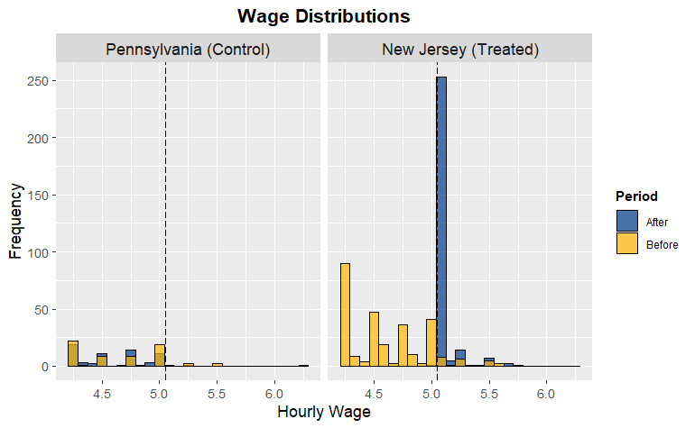

Check the histogram of the outcome (employment) before and after:

```
# Combine data into a single data frame
data = data.frame(
  value = c(Y1, Y2),
  period = factor(rep(c("Before", "After"), each = length(Y1))),
  W = factor(rep(W, 2))  # Repeat W for both periods
)

# Create the histogram plot
ggplot(data, aes(x = value, fill = period)) +
  geom_histogram(alpha = 0.7, position = "identity", bins = 30, color = "black") +
  labs(title = "Employment Distributions", x = "Full-time equivalents", y = "Frequency") +
  facet_wrap(~ W, labeller=as_labeller(c("0"="Pennsylvania (Control)", "1"="New Jersey (Treated)")))
```

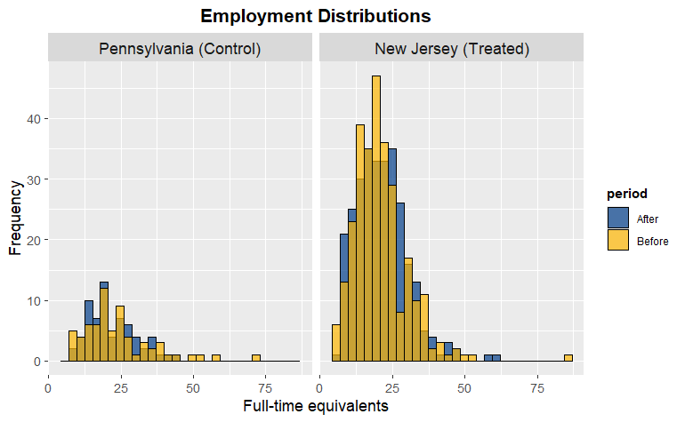

## Manual DiD estimates

Let’s calculate the required means. As a reminder we need the following quantities
$$\tau_{ATT} = E[Y_2
\mid W = 1] - E[Y_1 \mid W = 1] - \{E[Y_2 \mid W = 0] - E[Y_1 \mid W =
0]\}$$

```
# Separate the four groups
Y2W1 = Y2[W == 1]
Y1W1 = Y1[W == 1]
Y2W0 = Y2[W == 0]
Y1W0 = Y1[W == 0]

# The means
means = matrix(c(mean(Y1W0), mean(Y2W0) , mean(Y1W1), mean(Y2W1)), nrow = 2, byrow = TRUE)
rownames(means) = c("W=0", "W=1")
colnames(means) = c("Before", "After")
means
```

```
      Before    After
W=0 23.70455 21.82576
W=1 20.67825 21.07632
```

Plot the means:

```
# the standard errors
Y2W1_se = sd(Y2W1) / sqrt(sum(W))
Y1W1_se = sd(Y1W1) / sqrt(sum(W))
Y2W0_se = sd(Y2W0) / sqrt(sum(1-W))
Y1W0_se = sd(Y1W0) / sqrt(sum(1-W))

# Combine data into a single data frame
temp = data.frame(
  Mean = c(mean(Y2W1), mean(Y2W0), mean(Y1W1), mean(Y1W0)),
  SE = c(Y2W1_se, Y2W0_se, Y1W1_se, Y1W0_se),
  Period = factor(rep(c("2", "1"), each = 2)),
  W = factor(rep(c("W=1", "W=0"), times = 2))
)

# Create the ggplot
ggplot(temp, aes(x = Period, y = Mean, color = W, group = W)) +
  geom_point() + theme(legend.position = "none") +
  geom_line() +  # Add lines to connect the points
  # geom_errorbar(aes(ymin = Mean - 1.96 * SE, ymax = Mean + 1.96 * SE), width = 0.1) +
  labs(title = "Manual DiD estimates", x = "Period", y = "Full-time equivalents") +
  geom_text(data = temp %>% group_by(W) %>% slice(n()), angle = c(-34, 8),
            aes(label = c("Pennsylvania, W=0", "New Jersey, W=1")))
```

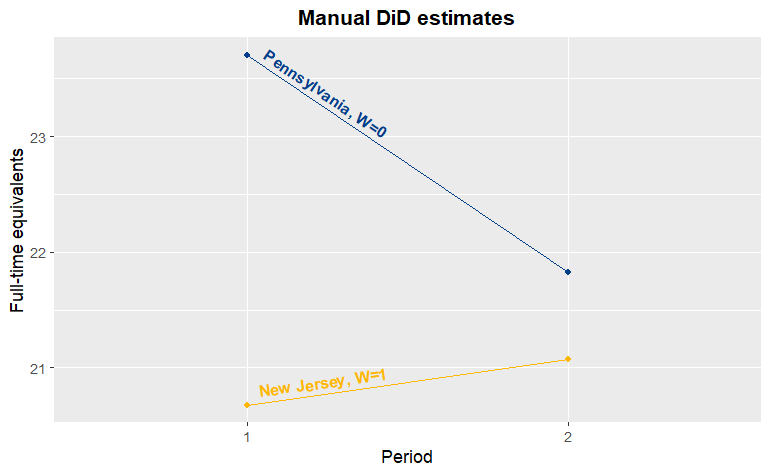

Now take the time differences:

```
EY2W1 = mean(Y2W1)
EY1W1 = mean(Y1W1)
EY2W0 = mean(Y2W0)
EY1W0 = mean(Y1W0)

# Time differences
NJ_diff = EY2W1 - EY1W1
PA_diff = EY2W0 - EY1W0

# Standard errors
NJ_diff_se = sqrt(Y2W1_se^2 + Y1W1_se^2)
PA_diff_se = sqrt(Y2W0_se^2 + Y1W0_se^2)

temp = cbind(c(NJ_diff,PA_diff),c(NJ_diff_se,PA_diff_se))
colnames(temp) = c("Time diff", "S.E.")
rownames(temp) = c("W=1","W=0")
temp
```

```
     Time diff      S.E.
W=1  0.3980702 0.7575704
W=0 -1.8787879 1.8262914
```

And finally the difference in differences and its standard error:

```
ATT = NJ_diff - PA_diff
ATT_se = sqrt(NJ_diff_se^2 + PA_diff_se^2)

temp = cbind(ATT,ATT_se)
colnames(temp) = c("ATT", "S.E.")
temp
```

```
          ATT     S.E.
[1,] 2.276858 1.977183
```

Note that we can equivalently run the regression
$$Y_{i,t} = \alpha + \beta_1 After_t + \beta_1 W_i
+ \tau [After \cdot W_i] + error_{i,t}$$

where we first need to bring the data from the wide to the long format:

```
Ylong = c(Y1,Y2)
Wlong = rep(W,2)
after = c(rep(0,length(W)),rep(1,length(W)))

summary(lm_robust(Ylong ~ Wlong * after))
```

```
Call:
lm_robust(formula = Ylong ~ Wlong * after)

Standard error type:  HC2

Coefficients:
            Estimate Std. Error t value  Pr(>|t|) CI Lower CI Upper  DF
(Intercept)   23.705      1.520  15.591 3.032e-47   20.719   26.690 698
Wlong         -3.026      1.616  -1.872 6.157e-02   -6.200    0.147 698
after         -1.879      1.826  -1.029 3.040e-01   -5.464    1.707 698
Wlong:after    2.277      1.977   1.152 2.499e-01   -1.605    6.159 698

Multiple R-squared:  0.008503 , Adjusted R-squared:  0.004241
F-statistic: 1.343 on 3 and 698 DF,  p-value: 0.2594
```

## Imputing the counterfactual outcome

There are many different ways how we can think about DiD. Let us revisit the identification under

- No anticipation (NA): $Y_1(1) = Y_1(0)$
- Parallel trends (PT): $\underbrace{E[Y_2(0) - Y_1(0) \mid W = 1]}_{\text{counterfactual trend}} = \underbrace{E[Y_2(0) - Y_1(0) \mid W = 0]}_{\text{factual trend}}$

We start with the observation that the missing piece is the average outcome of the treated group in period 2 in the absence of the treatment:
$$\begin{align}
E[Y_2(1) - Y_2(0)| W=1] &= E[Y_2(1)| W=1] - E[Y_2(0)| W=1] &
(LOE) \\
&= \underbrace{E[Y_2| W=1]}_{factual} - \underbrace{E[Y_2(0)|
W=1]}_{counterfactual} & (consistency) \\
\end{align}$$

Now we show that the counterfactual quantity can be identified as a combination of observed conditional means:

$$\begin{align}
E[Y_2(0)| W=1] &= E[Y_1(0) \mid W = 1] + E[Y_2(0) - Y_1(0) \mid W =
0] & (PT) \\
&= E[Y_1(1) \mid W = 1] + E[Y_2(0) - Y_1(0) \mid W = 0] & (NA)
\\
&= E[Y_1 \mid W = 1] + E[Y_2 - Y_1 \mid W = 0] & (consistency)
\end{align}$$

Computationally, the counterfactual outcome is constructed as

```
counterfactual = EY1W1 + PA_diff
counterfactual_se = sqrt(Y1W1_se^2 + PA_diff_se^2)
```

and graphically this can be illustrated as

```
# Combine data into a single data frame
temp = data.frame(
  Mean = c(mean(Y2W1), counterfactual, mean(Y1W1), mean(Y1W1)),
  SE = c(Y2W1_se, counterfactual_se, Y1W1_se, Y1W1_se),
  Period = factor(rep(c("2", "1"), each = 2)),
  W = factor(rep(c("factual", "counterfactual"), times = 2))
)

# Create the ggplot
ggplot(temp, aes(x = Period, y = Mean, color = W, group = W, linetype = W)) +
  geom_point() + theme(legend.position = "none") +
  geom_line() +  # Add lines to connect the points
  # geom_errorbar(aes(ymin = Mean - 1.96 * SE, ymax = Mean + 1.96 * SE), width = 0.1) +
  labs(title = "Imputing the counterfactual", x = "Period", y = "Full-time equivalents") +
  scale_linetype_manual(values = c("factual" = "solid", "counterfactual" = "dashed")) +
  geom_text(data = temp %>% group_by(W) %>% slice(n()), angle = c(-43, 11),
            aes(label = c("counterfactual", "factual")))
```

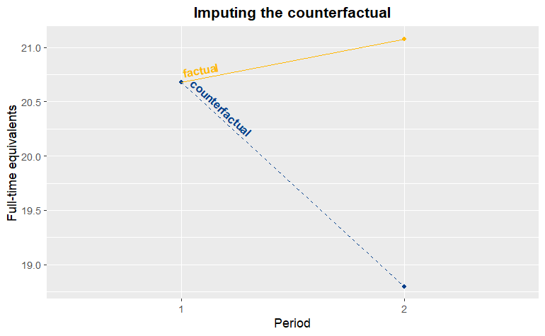

The difference of the two points in period two is equivalent to the above estimated DiD:

```
print(rbind("ATT:" = EY2W1 - counterfactual,
            "St. error:" = sqrt(Y2W1_se^2 + counterfactual_se^2)))
```

```
               [,1]
ATT:       2.276858
St. error: 1.977183
```